# Chapter 4: Meta-analysis Using Bayesian Methods

Bob

2025-02-26

# TO DO:

- Models `Cholesterol_prior_sens` and `asprin_logistic_random_1_priors_sensitivity` fail with `Attempt to redefine node` errors. These chunks are set to `eval=FALSE`.
- Describe the point of each model.
- Be sure appropriate outputs are summarized or plotted. What other plots are relevant?
- Clean up code: re-use datasets as appropriate, smarter table loading (compute k from the length of the dataframe; use this value to generate initial values), …

```r
library('rjags')
library('coda')
library('jagshelper')
library('jagsUI')
library('mcmcplots')  # caterplot
library('dplyr')
```

# Aspirin

## `asprin_normal_fixed_1.txt`

This is the model from Figure 4.1 (with a few extra digits of precision in the data).

```r
model_code <- "model
{
  for (i in 1:Nstud)
    {
      P[i] <- 1/V[i]
      y[i] ~ dnorm(d, P[i])
    }
    d ~ dnorm(0, 1.0E-5)
    OR <- exp(d)
}" %>% textConnection

# DATA
data <- list(
  y=c(.3289011, .3845458, .2195622, .2222206, .2254672, -.1246363, .1109658),
  V=c(.0388957,.0411673,.0204915,.0647646,.0351996,.0096167,.0015062),
  Nstud=7
)

# INITIAL VALUES: This is a list of lists, one per chain.
initial_values <- list(
  list(d=0)
)

results <- jags(
  data = data,
  inits = initial_values,
  parameters.to.save = c("OR", "d"),
  model.file = model_code,
  n.chains = length(initial_values),
  n.adapt = 100,
  n.iter = 50000,
  n.burnin = 20000,
  n.thin = 2
)
```

```
##
## Processing function input.......
##
## Done.
##
##
##
## Adaptive phase, 100 iterations x 1 chains
## If no progress bar appears JAGS has decided not to adapt
##
##
##  Burn-in phase, 20000 iterations x 1 chains
##
##
## Sampling from joint posterior, 30000 iterations x 1 chains
##
##
## Calculating statistics.......
##
## Done.
```

```r
summary(results)
```

```
##                mean         sd       2.5%         25%        50%        75%
## OR        1.1152989 0.03696172  1.0451559  1.08994876  1.1146526  1.1396453
## d         0.1085738 0.03312429  0.0441661  0.08613068  0.1085428  0.1307171
## deviance -3.7405957 1.41609146 -4.7387208 -4.64041566 -4.2876320 -3.4085808
##              97.5% Rhat n.eff overlap0      f
## OR       1.1895226   NA     1        0 1.0000
## d        0.1735520   NA     1        0 0.9992
## deviance 0.1489985   NA     1        1 0.9716
```

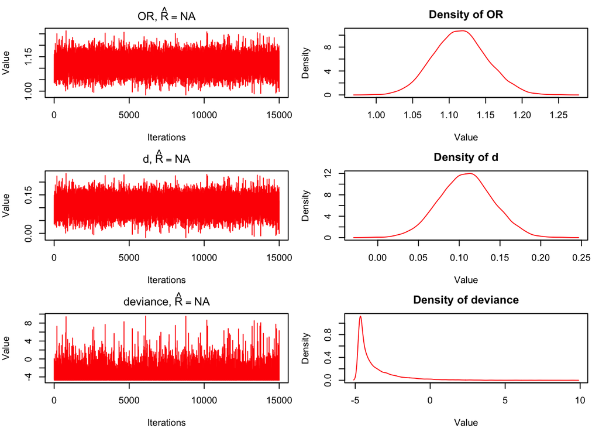

```r
plot(results)
```

## `asprin_normal_random_1.txt`

This is the model from Figure 4.3, except it uses lower case for the y[] variable vector.

```r
model_code <- "model
{
  for (i in 1:Nstud)
    {
      P[i] <- 1/V[i]
      y[i] ~ dnorm(delta[i], P[i])
      delta[i] ~ dnorm(d, prec)
    }
    d ~ dnorm(0, 1.0E-5)
    OR <- exp(d)
    tau ~ dunif(0,10)
    tau.sq <- tau*tau
    prec <- 1/(tau.sq)
}" %>% textConnection

# DATA  (the same as for the fixed effects model above)
data <- list(
  y=c(.3289011, .3845458, .2195622, .2222206, .2254672, -.1246363, .1109658),
  V=c(.0388957,.0411673,.0204915,.0647646,.0351996,.0096167,.0015062),
  Nstud=7
)

# INITIAL VALUES: This is a list of lists, one per chain.
initial_values <- list(
  list(d = 0, tau = 1, delta = c(0,0,0,0,0,0,0))
)

results <- jags(
  data = data,
  inits = initial_values,
  parameters.to.save = c("OR", "d", "prec", "tau.sq"),
  model.file = model_code,
  n.chains = length(initial_values),
  n.adapt = 100,
  n.iter = 50000,
  n.burnin = 20000,
  n.thin = 2
)
```

```
##
## Processing function input.......
##
## Done.
##
##
##
## Adaptive phase, 100 iterations x 1 chains
## If no progress bar appears JAGS has decided not to adapt
##
##
##  Burn-in phase, 20000 iterations x 1 chains
##
##
## Sampling from joint posterior, 30000 iterations x 1 chains
##
##
## Calculating statistics.......
##
## Done.
```

```r
summary(results)
```

```
##                   mean           sd          2.5%           25%         50%
## OR           1.1645720 1.141994e-01  9.841484e-01   1.095626762  1.14786485
## d            0.1478211 9.414489e-02 -1.597863e-02   0.091326585  0.13790357
## prec     21629.6403547 5.991931e+05  5.219621e+00  22.014883357 50.27067209
## tau.sq       0.0378028 5.715519e-02  6.832329e-05   0.006656983  0.01989232
## deviance    -7.8932649 3.368055e+00 -1.308174e+01 -10.519613994 -8.32468302
##                   75%         97.5% Rhat n.eff overlap0         f
## OR         1.21790831     1.4302054   NA     1        0 1.0000000
## d          0.19713488     0.3578180   NA     1        1 0.9651333
## prec     150.21819015 14636.3015723   NA     1        0 1.0000000
## tau.sq     0.04542382     0.1915848   NA     1        0 1.0000000
## deviance  -5.55617578    -0.6786817   NA     1        0 0.9823333
```

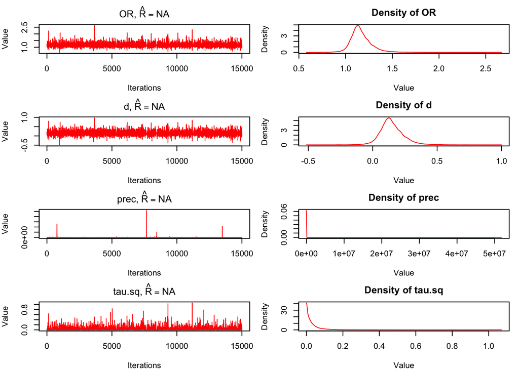

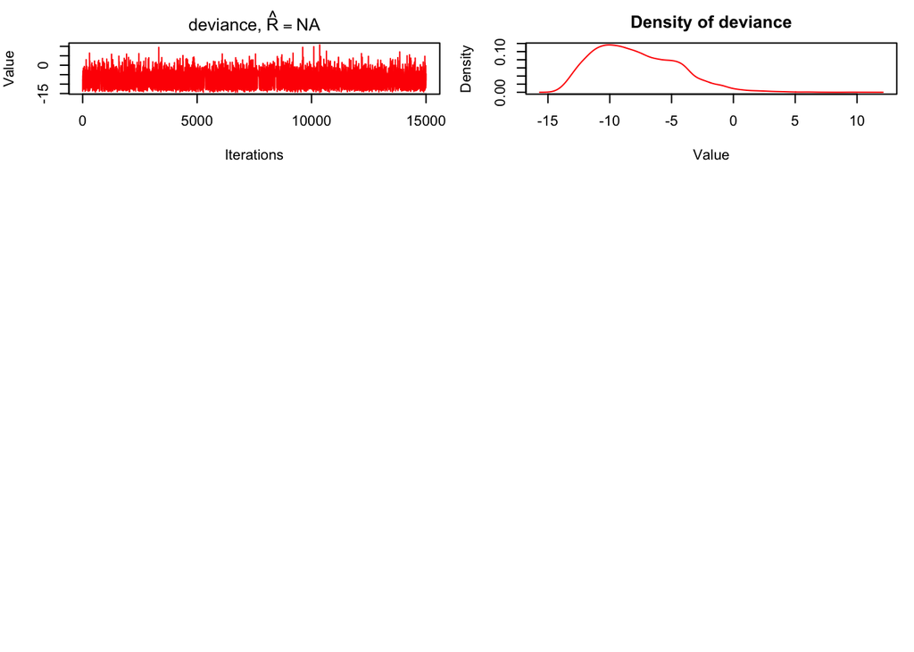

```r
plot(results)
```

## `asprin_logistic_random_1.txt`

This is the model from Figure 4.5 (except that the line `OR <- exp(d)` is in a different place).

```r
model_code <- "model
{
  for( i in 1 : Nstud ) {
    rA[i] ~ dbin(pA[i], nA[i])
    rB[i] ~ dbin(pB[i], nB[i])
    logit(pA[i]) <- mu[i]
    logit(pB[i]) <- mu[i] + delta[i]
    mu[i] ~ dnorm(0.0,1.0E-5)
    delta[i] ~ dnorm(d, prec)
  }
  OR <- exp(d)   # !!! this line comes last in Figure 4.5
  d ~ dnorm(0.0,1.0E-6)
  tau ~ dunif(0,10)
  tau.sq <- tau*tau
  prec <- 1/(tau.sq)
}" %>% textConnection

# DATA
data <- list(
  rA=c(49,44,102,32,85,246,1570),
  rB=c(67,64,126,38,52,219,1720),
  nA=c(615,758,832,317,810,2267,8587),
  nB=c(624,771,850,309,406,2257,8600),
  Nstud=7
)


# INITIAL VALUES: This is a list of lists, one per chain.
initial_values <- list(
  list(d=0, tau=1, delta=c(0,0,0,0,0,0,0), mu=c(0,0,0,0,0,0,0))
)

results <- jags(
  data = data,
  inits = initial_values,
  parameters.to.save = c("OR", "d", "prec", "tau.sq"),
  model.file = model_code,
  n.chains = length(initial_values),
  n.adapt = 100,
  n.iter = 50000,
  n.burnin = 20000,
  n.thin = 2
)
```

```
##
## Processing function input.......
##
## Done.
##
##
##
## Adaptive phase, 100 iterations x 1 chains
## If no progress bar appears JAGS has decided not to adapt
##
##
##  Burn-in phase, 20000 iterations x 1 chains
##
##
## Sampling from joint posterior, 30000 iterations x 1 chains
##
##
## Calculating statistics.......
##
## Done.
```

```r
summary(results)
```

```
##                  mean           sd         2.5%          25%         50%
## OR       1.162624e+00 1.177557e-01  0.978756661   1.09188943   1.1472835
## d        1.458876e-01 9.672726e-02 -0.021472228   0.08790962   0.1373970
## prec     4.822470e+04 1.173885e+06  5.068340327  21.59524746  48.9994301
## tau.sq   3.948965e-02 6.546705e-02  0.000112947   0.00691029   0.0204084
## deviance 1.045481e+02 5.127595e+00 96.173803757 100.85093814 103.9836227
##                   75%        97.5% Rhat n.eff overlap0         f
## OR         1.21581831    1.4360722   NA     1        0 1.0000000
## d          0.19541735    0.3619118   NA     1        1 0.9619333
## prec     144.71174872 8853.7076360   NA     1        0 1.0000000
## tau.sq     0.04630649    0.1973033   NA     1        0 1.0000000
## deviance 107.65098339  115.9542566   NA     1        0 1.0000000
```

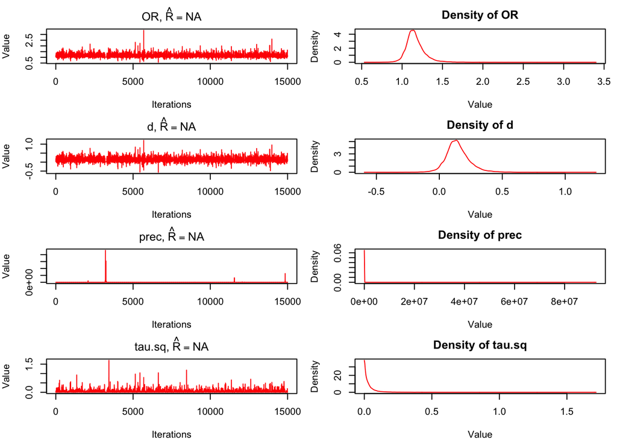

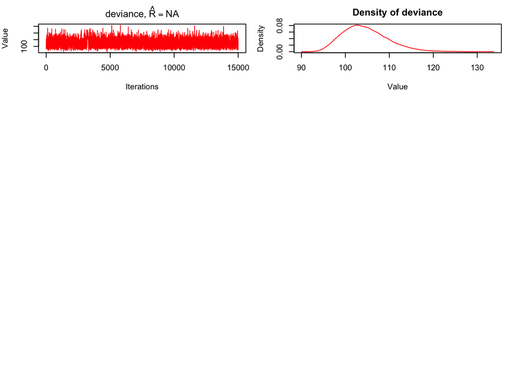

```r
plot(results)
```

## `asprin_logistic_random1_predict.txt`

```r
model_code <- "model
{
  for( i in 1 : Nstud ) {
    rA[i] ~ dbin(pA[i], nA[i])
    rB[i] ~ dbin(pB[i], nB[i])
    logit(pA[i]) <- mu[i]
    logit(pB[i]) <- mu[i] + delta[i]
    mu[i] ~ dnorm(0.0,1.0E-5)
    delta[i] ~ dnorm(d, prec)
  }

  OR <- exp(d)
  d ~ dnorm(0.0,1.0E-6)
  tau~dunif(0,10)
  tau.sq<-tau*tau
  prec<-1/(tau.sq)

  d.new ~ dnorm(d, prec)
  OR.new <-exp(d.new)
}" %>% textConnection

# DATA
data <- list(
  rA=c(49,44,102,32,85,246,1570),
  rB=c(67,64,126,38,52,219,1720),
  nA=c(615,758,832,317,810,2267,8587),
  nB=c(624,771,850,309,406,2257,8600),
  Nstud=7
)


# INITIAL VALUES: This is a list of lists, one per chain.
initial_values <- list(
  list(d=0, tau =1, delta=c(0,0,0,0,0,0,0), mu=c(0,0,0,0,0,0,0))
)

results <- jags(
  data = data,
  inits = initial_values,
  parameters.to.save = c("OR", "OR.new", "d.new", "delta", "tau.sq"),
  model.file = model_code,
  n.chains = length(initial_values),
  n.adapt = 100,
  n.iter = 50000,
  n.burnin = 20000,
  n.thin = 2
)
```

```
##
## Processing function input.......
##
## Done.
##
##
##
## Adaptive phase, 100 iterations x 1 chains
## If no progress bar appears JAGS has decided not to adapt
##
##
##  Burn-in phase, 20000 iterations x 1 chains
##
##
## Sampling from joint posterior, 30000 iterations x 1 chains
##
##
## Calculating statistics.......
##
## Done.
```

```r
summary(results)
```

```
##                  mean         sd          2.5%           25%          50%
## OR         1.16050972 0.11241780  0.9761093593   1.091393558   1.14479987
## OR.new     1.18317541 0.30282888  0.7528738817   1.043054132   1.13824698
## d.new      0.14328229 0.21693404 -0.2838575639   0.042153075   0.12948934
## delta[1]   0.20403642 0.13802026 -0.0278281175   0.108301822   0.18442595
## delta[2]   0.22412210 0.14980740 -0.0125350339   0.114910817   0.20069364
## delta[3]   0.17326950 0.11126193 -0.0270771993   0.098250797   0.16213449
## delta[4]   0.16060434 0.14851230 -0.1166260005   0.071822105   0.14381079
## delta[5]   0.16608248 0.12803446 -0.0724465332   0.084188257   0.15358247
## delta[6]  -0.02643911 0.10143087 -0.2348534689  -0.095537687  -0.02185289
## delta[7]   0.11188416 0.03700945  0.0397053838   0.087002345   0.11152945
## tau.sq     0.03853473 0.06019465  0.0001254582   0.007187104   0.02036463
## deviance 104.46316250 5.02309534 96.2290695290 100.790473871 103.96906653
##                   75%       97.5% Rhat n.eff overlap0         f
## OR         1.21447529   1.4240333   NA     1        0 1.0000000
## OR.new     1.26689202   1.8402076   NA     1        0 1.0000000
## d.new      0.23656667   0.6098784   NA     1        1 0.8220000
## delta[1]   0.28635125   0.5145689   NA     1        1 0.9584667
## delta[2]   0.31399875   0.5642215   NA     1        1 0.9680000
## delta[3]   0.24273346   0.4153319   NA     1        1 0.9556000
## delta[4]   0.24154127   0.4936054   NA     1        1 0.8950667
## delta[5]   0.24049370   0.4513281   NA     1        1 0.9271333
## delta[6]   0.05021374   0.1471257   NA     1        1 0.5820667
## delta[7]   0.13713613   0.1845428   NA     1        0 0.9987333
## tau.sq     0.04663493   0.1926037   NA     1        0 1.0000000
## deviance 107.51652691 115.5609445   NA     1        0 1.0000000
```

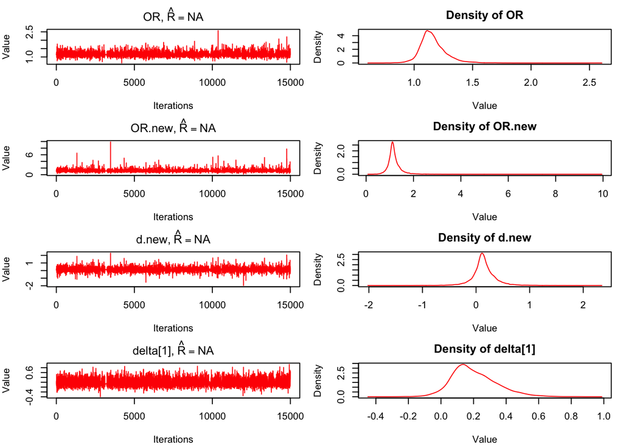

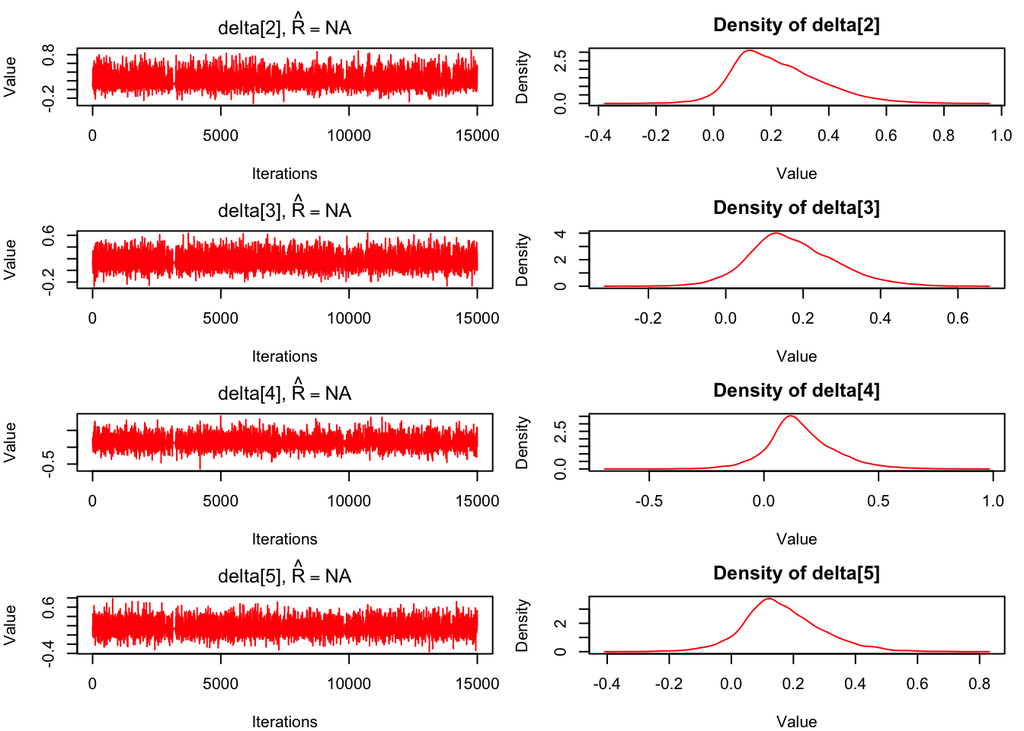

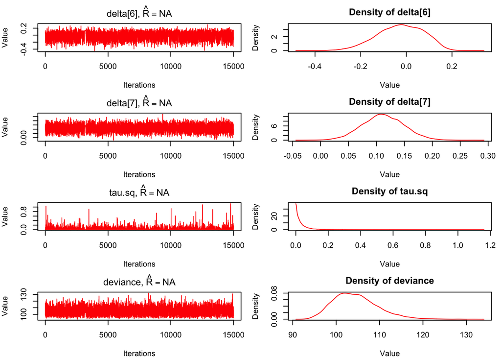

```r
plot(results)
```

## `asprin_logistic_random_1_priors_sensitivity`

```
RUNTIME ERROR:
Compilation error on line 13.
Attempt to redefine node rBx[1,1]
```

```r
model_code <- "
model
    {

  ## replicating the data 2 times to fit to 3 models in total where j indexes alternative prior distributions

  for (j in 1:3)
    {

      for( i in 1 : Nstud )
      {
        rAx[j,i] ~ dbin(pA[j,i], nA[i])
        rAx[j,i] <- rA[i]
        rBx[j,i] ~ dbin(pB[j,i], nB[i])
        rBx[j,i] <- rB[i]
        logit(pA[j,i]) <- mu[j,i]
        logit(pB[j,i]) <- mu[j,i] + delta[j,i]
        mu[j,i] ~  dnorm(0.0,1.0E-5)
        delta[j,i] ~ dnorm(d[j], prec[j])
      }
    }

  for (j in 1:3)
    {
      OR[j] <- exp(d[j])
      d[j] ~ dnorm(0.0,1.0E-6)
      m[j]~dnorm(0.0,1.0E-6)
    }


  # Setting three different priors for the between study variance

  prec[1] <- 1/tau.sq[1]
  tau.sq[1] <- tau[1]*tau[1]
  tau[1] ~ dnorm(0,1.0E-6)I(0,)

  prec[2] ~ dgamma(0.001,0.001)
  tau.sq[2] <- 1/prec[2]
  tau[2] <- sqrt(tau.sq[2])

  tau[3] ~ dunif(0,10)
  tau.sq[3] <- tau[3]*tau[3]
  prec[3] <- 1/tau.sq[3]

    }
" %>% textConnection

# DATA
data <- list(
  rA=c(49,44,102,32,85,246,1570),
  rB=c(67,64,126,38,52,219,1720),
  nA=c(615,758,832,317,810,2267,8587),
  nB=c(624,771,850,309,406,2257,8600),
  Nstud=7
)


# INITIAL VALUES: This is a list of lists, one per chain.
initial_values <- list(
  # WinBUGS code has extra closing parentheses (???)
  list(
    prec=c(NA,0.1,NA),
    tau=c(0.01, NA, 0.01),
    mu = structure(
      .Data=c(0,0,0,0,0,0,0,  0,0,0,0,0,0,0,  0,0,0,0,0,0,0),
      .Dim=c(3,7)),
    delta = structure(
      .Data=c(0,0,0,0,0,0,0,   0,0,0,0,0,0,0,   0,0,0,0,0,0,0),
      .Dim=c(3,7)),
    d =c(0.1,0.1,0.1)
  )

)

results <- jags(
  data = data,
  inits = initial_values,
  parameters.to.save = c("OR", "d", "delta", "tau.sq", "rAx"),
  model.file = model_code,
  n.chains = length(initial_values),
  n.adapt = 100,
  n.iter = 50000,
  n.burnin = 20000,
  n.thin = 2
)

summary(results)

plot(results)
```

# Cholesterol

## `chol_model.txt`, `chol_data.txt`

```
Error parsing model file:
syntax error on line 5 near "var"
```

Maybe `var` is a reserved word or something? I changed it to `V` (as in the next model), which seems to work.

```r
model_code <- "model
{
  for (i in 1:k)
  {
    precision[i] <- 1/V[i]
    logor[i] ~ dnorm(theta, precision[i])
  }
    theta ~ dnorm(0, 1.0E-5)
    OR <- exp(theta)
}
" %>% textConnection

# DATA
data <- list(k=34)

data_df <- "logor   V
0.4893853   0.1987757
-0.0683811  0.054427
-0.4876372  0.0730886
-0.1630902  0.1108992
1.469676    1.186739
0.0057637   0.0608936
-0.1496961  0.0799553
-1.94591    2.351288
-0.0470209  0.0194635
-0.3824268  0.0552552
-0.5508629  0.0615112
-0.0984401  0.0510244
0.2939126   0.1708592
-0.4883528  1.582492
-0.4354064  0.0030637
-0.2885568  0.0496847
0.4696847   0.0716345
0.2692525   0.0101539
-1.563976   0.8819983
-0.3517397  0.3733933
-0.0480808  0.0298812
-1.109251   2.687944
0.0129744   0.0469846
-0.4124823  0.0383304
-0.0233855  0.0200697
0.0803459   0.0082181
-0.2820902  0.0420423
-1.098612   2.707904
0.521464    2.696409
-0.2501722  0.477032
1.025401    0.3643915
-0.7528253  0.0676265
-1.580711   2.272708
0.5030903   0.1426682" %>% read.delim(text=., sep="\t")

for (colname in names(data_df)){
  data[[colname]] <- data_df[[colname]]
}



results <- jags(
  data = data,
  # inits = initial_values,
  parameters.to.save = c("OR", "theta"),
  model.file = model_code,
  n.chains = 1, # length(initial_values),
  # n.adapt = 100,
  n.iter = 50000,
  n.burnin = 20000 #, n.thin = 2
)
```

```
##
## Processing function input.......
##
## Done.
##
##
##
## Adaptive phase.....
## Adaptive phase complete
##
##
##  Burn-in phase, 20000 iterations x 1 chains
##
##
## Sampling from joint posterior, 30000 iterations x 1 chains
##
##
## Calculating statistics.......
##
## Done.
```

```r
summary(results)
```

```
##                mean         sd       2.5%        25%        50%        75%
## OR        0.8450305 0.02749427  0.7924873  0.8262619  0.8446433  0.8633661
## theta    -0.1689116 0.03252920 -0.2325788 -0.1908434 -0.1688408 -0.1469165
## deviance 83.6286591 1.43087693 82.6188634 82.7195481 83.0783422 83.9626219
##               97.5% Rhat n.eff overlap0 f
## OR        0.8997953   NA     1        0 1
## theta    -0.1055879   NA     1        0 1
## deviance 87.7329839   NA     1        0 1
```

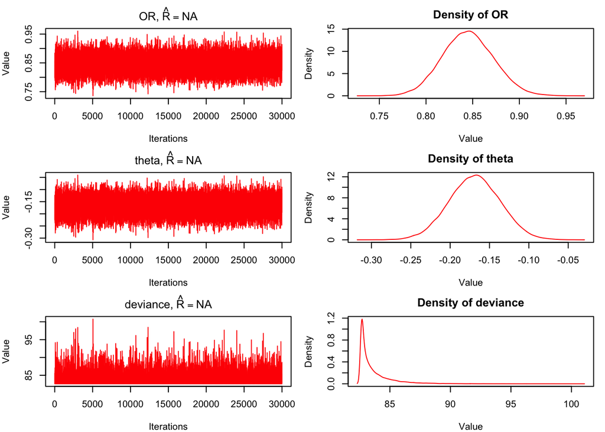

```r
plot(results)
```

# `Cholesterol_fixed.txt`

This is the file for Model 4.1 from the Exercises, referenced on p. 89.

Model 1: Generic fixed effect model applied to the cholesterol lowering dataset

```r
model_code <- "model
{
  for (i in 1:k)
  {
    P[i] <- 1/V[i]
    logor[i] ~ dnorm(d, P[i])
  }
    d ~ dnorm(0, 1.0E-5)
    OR <- exp(d)
}" %>% textConnection

# DATA: re-used from previous model. Here the name of the second column in the data table is `V` instead of `var`. I changed that in the previous model because the name `var` seemed to be causing problems.

# data <- list(k=34)
#
# data_df <- "logor V
# 0.4893853 0.1987757
# -0.0683811    0.054427
# -0.4876372    0.0730886
# -0.1630902    0.1108992
# 1.469676  1.186739
# 0.0057637 0.0608936
# -0.1496961    0.0799553
# -1.94591  2.351288
# -0.0470209    0.0194635
# -0.3824268    0.0552552
# -0.5508629    0.0615112
# -0.0984401    0.0510244
# 0.2939126 0.1708592
# -0.4883528    1.582492
# -0.4354064    0.0030637
# -0.2885568    0.0496847
# 0.4696847 0.0716345
# 0.2692525 0.0101539
# -1.563976 0.8819983
# -0.3517397    0.3733933
# -0.0480808    0.0298812
# -1.109251 2.687944
# 0.0129744 0.0469846
# -0.4124823    0.0383304
# -0.0233855    0.0200697
# 0.0803459 0.0082181
# -0.2820902    0.0420423
# -1.098612 2.707904
# 0.521464  2.696409
# -0.2501722    0.477032
# 1.025401  0.3643915
# -0.7528253    0.0676265
# -1.580711 2.272708
# 0.5030903 0.1426682" %>% read.delim(text=., sep="\t")
#
# for (colname in names(data_df)){
#   data[[colname]] <- data_df[[colname]]
# }

# INITIAL VALUES: This is a list of lists, one per chain.
initial_values <- list(
  list(d=0)
)

results <- jags(
  data = data,
  inits = initial_values,
  parameters.to.save = c("OR", "d"),
  model.file = model_code,
  n.chains = length(initial_values),
  n.adapt = 100,
  n.iter = 50000,
  n.burnin = 20000,
  n.thin = 2
)
```

```
##
## Processing function input.......
##
## Done.
##
##
##
## Adaptive phase, 100 iterations x 1 chains
## If no progress bar appears JAGS has decided not to adapt
##
##
##  Burn-in phase, 20000 iterations x 1 chains
##
##
## Sampling from joint posterior, 30000 iterations x 1 chains
##
##
## Calculating statistics.......
##
## Done.
```

```r
summary(results)
```

```
##                mean         sd       2.5%        25%        50%        75%
## OR        0.8448806 0.02748374  0.7927164  0.8259972  0.8443407  0.8634758
## d        -0.1690888 0.03252295 -0.2322897 -0.1911639 -0.1691992 -0.1467894
## deviance 83.6282104 1.41682782 82.6188905 82.7235548 83.0885217 83.9742583
##               97.5% Rhat n.eff overlap0 f
## OR        0.8992803   NA     1        0 1
## d        -0.1061605   NA     1        0 1
## deviance 87.7003888   NA     1        0 1
```

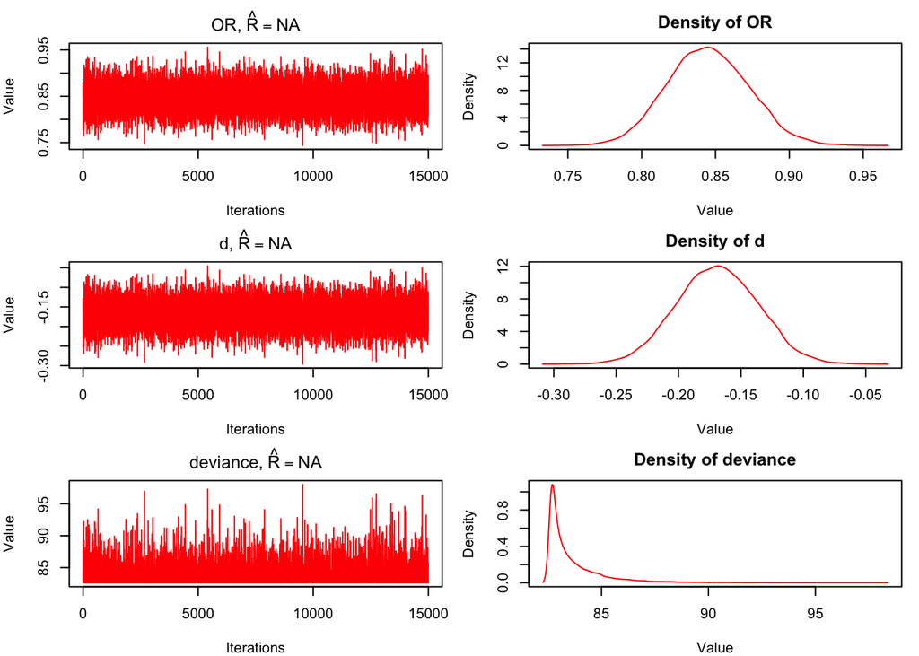

```r
plot(results)
```

## `Cholesterol_random.txt`

This is the file for Model 4.2 from the Exercises, referenced on p. 90.

Model 2: Generic random effect model applied to the cholesterol lowering dataset

```r
model_code <- "model
{
  for (i in 1:k)
    {
      P[i] <- 1/V[i]
      logor[i] ~ dnorm(delta[i], P[i])
      delta[i] ~ dnorm(d, prec)
    }
    d ~ dnorm(0, 1.0E-5)
    OR <- exp(d)

    tau ~ dunif(0,10)
    tau.sq <- tau*tau
    prec <- 1/(tau.sq)
    d.new ~ dnorm(d, prec)
}" %>% textConnection

# DATA: re-used from previous chunks.


initial_values <- list(
  list(d=0,
       delta=c(0,0,0,0,0,0,0,0,0,0,0,0,0,0,0,0,0,0,0,0,0,0,0,0,0,0,0,0,0,0,0,0,0,0),
       d.new=0)
)

results <- jags(
  data = data,
  inits = initial_values,
  parameters.to.save = c("OR", "d"),
  model.file = model_code,
  n.chains = length(initial_values),
  n.adapt = 100,
  n.iter = 50000,
  n.burnin = 20000,
  n.thin = 2
)
```

```
##
## Processing function input.......
##
## Done.
##
##
##
## Adaptive phase, 100 iterations x 1 chains
## If no progress bar appears JAGS has decided not to adapt
##
##
##  Burn-in phase, 20000 iterations x 1 chains
##
##
## Sampling from joint posterior, 30000 iterations x 1 chains
##
##
## Calculating statistics.......
##
## Done.
```

```r
summary(results)
```

```
##                mean         sd       2.5%        25%        50%         75%
## OR        0.8915307 0.06067547  0.7778188  0.8511636  0.8899601  0.92992138
## d        -0.1171261 0.06799461 -0.2512617 -0.1611510 -0.1165787 -0.07265524
## deviance 27.0040873 6.39403945 15.5219282 22.5070573 26.6662128 31.11206114
##                97.5% Rhat n.eff overlap0         f
## OR        1.01577115   NA     1        0 1.0000000
## d         0.01564807   NA     1        1 0.9603333
## deviance 40.42884808   NA     1        0 1.0000000
```

## `Cholesterol_random_logistic.txt`

This is the file for Model 4.3 in the Exercises, p90.

```r
model_code <- "model
    {
       for( i in 1 : k ) {
        rA[i] ~ dbin(pA[i], nA[i])
           rB[i] ~ dbin(pB[i], nB[i])
        logit(pA[i]) <- mu[i]
        logit(pB[i]) <- mu[i] + delta[i]
        mu[i] ~ dnorm(0.0,1.0E-5)
        delta[i] ~ dnorm(d, prec)
       }
        OR <- exp(d)
        d ~ dnorm(0.0,1.0E-6)

        tau~dunif(0,10)
        tau.sq<-tau*tau
        prec<-1/(tau.sq)
    }

" %>% textConnection

# DATA
data <- list(k=34)

data_df <- "nB  nA  rB  rA
50  50  17  12
285 147 70  38
156 119 37  40
123 129 20  24
54  26  8   1
427 143 81  27
199 194 28  31
30  33  0   3
424 422 174 178
206 206 41  55
244 253 31  51
350 367 42  48
47  48  23  20
23  29  1   2
5552    2789    1025    723
1149    1129    37  48
221 237 39  28
5331    5296    236 181
88  30  2   3
71  72  5   7
1906    1900    68  71
94  94  0   1
2051    2030    44  43
279 276 61  82
1018    1015    111 113
4541    4516    269 248
421 417 49  62
48  49  0   1
94  52  1   0
79  78  4   5
6582    1663    33  3
204 202 28  51
30  60  0   4
311 317 19  12" %>% read.delim(text=., sep="\t")

for (colname in names(data_df)){
  data[[colname]] <- data_df[[colname]]
}

initial_values = list(
  list(d=0,
       tau=1,
       delta=c(0,0,0,0,0,0,0,0,0,0,0,0,0,0,0,0,0,0,0,0,0,0,0,0,0,0,0,0,0,0,0,0,0,0), # rep(0, data$k)
       mu=c(0,0,0,0,0,0,0,0,0,0,0,0,0,0,0,0,0,0,0,0,0,0,0,0,0,0,0,0,0,0,0,0,0,0))
  )

results <- jags(
  data = data,
  inits = initial_values,
  parameters.to.save = c("OR", "theta"),
  model.file = model_code,
  n.chains = length(initial_values),
  n.adapt = 100,
  n.iter = 50000,
  n.burnin = 20000 #, n.thin = 2
)
```

```
##
## Processing function input.......
##
## Done.
##
##
##
## Adaptive phase, 100 iterations x 1 chains
## If no progress bar appears JAGS has decided not to adapt
##
##
##  Burn-in phase, 20000 iterations x 1 chains
##
##
## Sampling from joint posterior, 30000 iterations x 1 chains
##
```

```
##
## Calculating statistics.......
##
## Done.
```

```r
summary(results)
```

```
##                 mean          sd        2.5%         25%         50%
## OR         0.8931823  0.06126147   0.7781396   0.8522584   0.8916462
## deviance 385.7780612 10.64095390 366.5683382 378.2695405 385.2217624
##                  75%      97.5% Rhat n.eff overlap0 f
## OR         0.9323971   1.019701   NA     1        0 1
## deviance 392.6394376 408.043277   NA     1        0 1
```

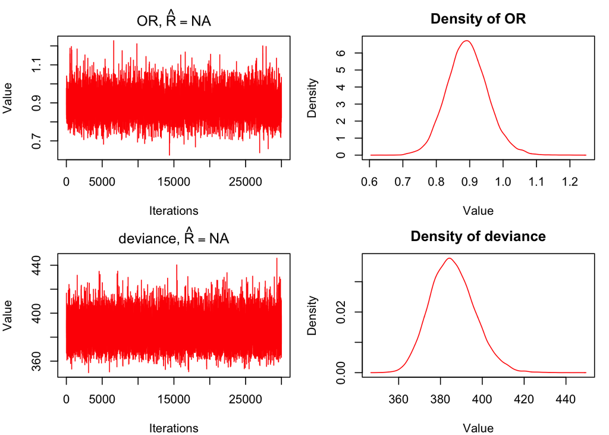

```r
plot(results)
```

## `Cholesterol_random_logistic_2`

Also referenced on p90.

Model 3 (Cont) Question 5: Direct OR model applied to the cholesterol lowering dataset

```r
model_code <- "

model
{
  for( i in 1 : k ) {
    rA[i] ~ dbin(pA[i], nA[i])
    rB[i] ~ dbin(pB[i], nB[i])
    logit(pA[i]) <- mu[i]
    logit(pB[i]) <- mu[i] + delta[i]
    mu[i] ~ dnorm(0.0,1.0E-5)
    delta[i] ~ dnorm(d, prec)
  }
  OR <- exp(d)
  d ~ dnorm(0.0,1.0E-6)

  tau~dunif(0,10)
  tau.sq<-tau*tau
  prec<-1/(tau.sq)

  # Storing theta.pooled in delta[37] to add to caterpillar plot
  delta[37] <- d

  # Replicate from a predictive distribution for a future study
  delta[39] ~ dnorm(d, prec)

}
" %>% textConnection

# DATA
data <- list(k=34)

data_df <- "nB  nA  rB  rA
50  50  17  12
285 147 70  38
156 119 37  40
123 129 20  24
54  26  8   1
427 143 81  27
199 194 28  31
30  33  0   3
424 422 174 178
206 206 41  55
244 253 31  51
350 367 42  48
47  48  23  20
23  29  1   2
5552    2789    1025    723
1149    1129    37  48
221 237 39  28
5331    5296    236 181
88  30  2   3
71  72  5   7
1906    1900    68  71
94  94  0   1
2051    2030    44  43
279 276 61  82
1018    1015    111 113
4541    4516    269 248
421 417 49  62
48  49  0   1
94  52  1   0
79  78  4   5
6582    1663    33  3
204 202 28  51
30  60  0   4
311 317 19  12" %>% read.delim(text=., sep="\t")

for (colname in names(data_df)){
  data[[colname]] <- data_df[[colname]]
}

initial_values = list(
  list(
    d=0,
    tau=2,
    delta=c(0,0,0,0,0,0,0,0,0,0,0,0,0,0,0,0,0,0,0,0,0,0,0,0,0,0,0,0,0,0,0,0,0,0,NA,NA,NA,NA,1),
    mu=c(0,0,0,0,0,0,0,0,0,0,0,0,0,0,0,0,0,0,0,0,0,0,0,0,0,0,0,0,0,0,0,0,0,0))

)


results <- jags(
  data = data,
  inits = initial_values,
  parameters.to.save = c("OR", "theta"),
  model.file = model_code,
  n.chains = length(initial_values),
  n.adapt = 100,
  n.iter = 50000,
  n.burnin = 20000 #, n.thin = 2
)
```

```
##
## Processing function input.......
##
## Done.
##
##
##
## Adaptive phase, 100 iterations x 1 chains
## If no progress bar appears JAGS has decided not to adapt
##
##
##  Burn-in phase, 20000 iterations x 1 chains
##
##
## Sampling from joint posterior, 30000 iterations x 1 chains
##
```

```
##
## Calculating statistics.......
##
## Done.
```

```r
summary(results)
```

```
##                 mean          sd        2.5%         25%         50%
## OR         0.8942955  0.06173935   0.7780684   0.8531266   0.8924514
## deviance 385.6649302 10.77528285 365.9397795 378.1703937 385.1026346
##                  75%      97.5% Rhat n.eff overlap0 f
## OR         0.9331826   1.022737   NA     1        0 1
## deviance 392.6972622 408.218181   NA     1        0 1
```

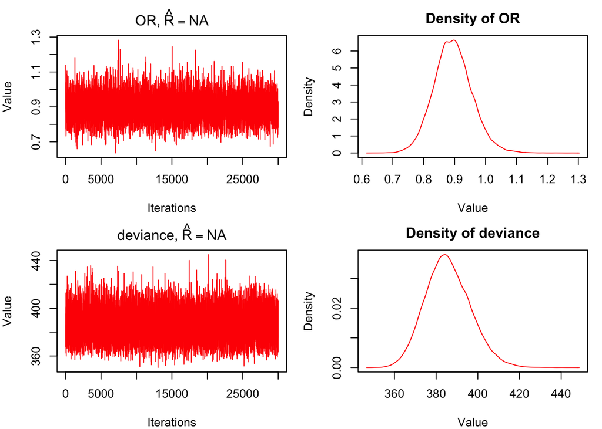

```r
plot(results)
```

## `Cholesterol_prior_sens`

This file is referenced for Model 4.4, p91.

Model 4: Direct OR model with built in sensitivity analysis to prior

```
RUNTIME ERROR:
Compilation error on line 14.
Attempt to redefine node rBx[1,1]
```

```r
model_code <- "
model
{

  ## replicating the data 2 times to fit to 3 models in total where j indexes alternative prior distributions

  for (j in 1:3)
  {

    for( i in 1 : k )
    {
      rAx[j,i] ~ dbin(pA[j,i], nA[i])
      rAx[j,i] <- rA[i]
      rBx[j,i] ~ dbin(pB[j,i], nB[i])
      rBx[j,i] <- rB[i]
      logit(pA[j,i]) <- mu[j,i]
      logit(pB[j,i]) <- mu[j,i] + delta[j,i]
      mu[j,i] ~ dnorm(0.0,1.0E-5)
      delta[j,i] ~ dnorm(d[j], prec[j])
    }
  }

  for (j in 1:3)
  {
    OR[j] <- exp(d[j])
    d[j] ~ dnorm(0.0,1.0E-6)
    m[j] ~ dnorm(0.0,1.0E-6)
  }


  # Setting three different priors for the between study variance

  prec[1] <-1/tau.sq[1]
  tau.sq[1] <-tau[1]*tau[1]
  tau[1] ~ dnorm(0,1.0E-6)I(0,)

  prec[2] ~ dgamma(0.001,0.001)
  tau.sq[2] <- 1/prec[2]
  tau[2] <- sqrt(tau.sq[2])

  tau[3] ~ dunif(0,50)
  tau.sq[3] <- tau[3]*tau[3]
  prec[3] <- 1/tau.sq[3]

}" %>% textConnection

# DATA
data <- list(k=34)

data_df <- "nB  nA  rB  rA
50  50  17  12
285 147 70  38
156 119 37  40
123 129 20  24
54  26  8   1
427 143 81  27
199 194 28  31
30  33  0   3
424 422 174 178
206 206 41  55
244 253 31  51
350 367 42  48
47  48  23  20
23  29  1   2
5552    2789    1025    723
1149    1129    37  48
221 237 39  28
5331    5296    236 181
88  30  2   3
71  72  5   7
1906    1900    68  71
94  94  0   1
2051    2030    44  43
279 276 61  82
1018    1015    111 113
4541    4516    269 248
421 417 49  62
48  49  0   1
94  52  1   0
79  78  4   5
6582    1663    33  3
204 202 28  51
30  60  0   4
311 317 19  12" %>% read.delim(text=., sep="\t")

for (colname in names(data_df)){
  data[[colname]] <- data_df[[colname]]
}

initial_values = list(

  list(
    prec=c(NA,0.1,NA),
    tau=c(0.5, NA, 0.5),
    mu = structure(.Data=c(0,0,0,0,0,0,0,0,0,0,  0,0,0,0,0,0,0,0,0,0,  0,0,0,0,0,0,0,0,0,0,   0,0,0,0,
0,0,0,0,0,0,0,0,0,0,  0,0,0,0,0,0,0,0,0,0,  0,0,0,0,0,0,0,0,0,0,   0,0,0,0,
0,0,0,0,0,0,0,0,0,0,  0,0,0,0,0,0,0,0,0,0,  0,0,0,0,0,0,0,0,0,0,   0,0,0,0),.Dim=c(3,34)),

    delta = structure(.Data=c(
0,0,0,0,0,0,0,0,0,0,  0,0,0,0,0,0,0,0,0,0,  0,0,0,0,0,0,0,0,0,0,   0,0,0,0,
0,0,0,0,0,0,0,0,0,0,  0,0,0,0,0,0,0,0,0,0,  0,0,0,0,0,0,0,0,0,0,   0,0,0,0,
0,0,0,0,0,0,0,0,0,0,  0,0,0,0,0,0,0,0,0,0,  0,0,0,0,0,0,0,0,0,0,   0,0,0,0),.Dim=c(3,34)) #)
    ,
    d =c(0.1,0.1,0.1)
  )

)


results <- jags(
  data = data,
  inits = initial_values,
  parameters.to.save = c("deviance", "theta"),
  model.file = model_code,
  n.chains = length(initial_values),
  n.adapt = 100,
  n.iter = 50000,
  n.burnin = 20000 #, n.thin = 2
)

summary(results)

plot(results)
```